# IODS course project

Since we will perform Linear Discriminant Analysis (LDA) on the data frame, we scale it so that the mean of each variable will be zero and the standard deviation one. Here is a summary of the scaled variables.

```r
# center and standardize variables
boston_scaled <- scale(Boston)
# summaries of the scaled variables
summary(boston_scaled)
```

```
##       crim                 zn               indus
##  Min.   :-0.419367   Min.   :-0.48724   Min.   :-1.5563
##  1st Qu.:-0.410563   1st Qu.:-0.48724   1st Qu.:-0.8668
##  Median :-0.390280   Median :-0.48724   Median :-0.2109
##  Mean   : 0.000000   Mean   : 0.00000   Mean   : 0.0000
##  3rd Qu.: 0.007389   3rd Qu.: 0.04872   3rd Qu.: 1.0150
##  Max.   : 9.924110   Max.   : 3.80047   Max.   : 2.4202
##       chas              nox                rm               age
##  Min.   :-0.2723   Min.   :-1.4644   Min.   :-3.8764   Min.   :-2.3331
##  1st Qu.:-0.2723   1st Qu.:-0.9121   1st Qu.:-0.5681   1st Qu.:-0.8366
##  Median :-0.2723   Median :-0.1441   Median :-0.1084   Median : 0.3171
##  Mean   : 0.0000   Mean   : 0.0000   Mean   : 0.0000   Mean   : 0.0000
##  3rd Qu.:-0.2723   3rd Qu.: 0.5981   3rd Qu.: 0.4823   3rd Qu.: 0.9059
##  Max.   : 3.6648   Max.   : 2.7296   Max.   : 3.5515   Max.   : 1.1164
##       dis               rad               tax             ptratio
##  Min.   :-1.2658   Min.   :-0.9819   Min.   :-1.3127   Min.   :-2.7047
##  1st Qu.:-0.8049   1st Qu.:-0.6373   1st Qu.:-0.7668   1st Qu.:-0.4876
##  Median :-0.2790   Median :-0.5225   Median :-0.4642   Median : 0.2746
##  Mean   : 0.0000   Mean   : 0.0000   Mean   : 0.0000   Mean   : 0.0000
##  3rd Qu.: 0.6617   3rd Qu.: 1.6596   3rd Qu.: 1.5294   3rd Qu.: 0.8058
##  Max.   : 3.9566   Max.   : 1.6596   Max.   : 1.7964   Max.   : 1.6372
##      black             lstat              medv
##  Min.   :-3.9033   Min.   :-1.5296   Min.   :-1.9063
##  1st Qu.: 0.2049   1st Qu.:-0.7986   1st Qu.:-0.5989
##  Median : 0.3808   Median :-0.1811   Median :-0.1449
##  Mean   : 0.0000   Mean   : 0.0000   Mean   : 0.0000
##  3rd Qu.: 0.4332   3rd Qu.: 0.6024   3rd Qu.: 0.2683
##  Max.   : 0.4406   Max.   : 3.5453   Max.   : 2.9865
```

Moreover, since the target variable in LDA needs to be categorical, we create a categorical variable of the crime rate (from the scaled crime rate), using the quantiles as the break points in the categorical variable. We drop the old crime rate variable from the dataset and add the new categorical value to the scaled data set. Here you can see the table of the new variable crime.

```r
# change the object to data frame
boston_scaled <- as.data.frame(boston_scaled)
# create a quantile vector of crim
bins <- quantile(boston_scaled$crim)
# create a categorical variable 'crime'
crime <- cut(boston_scaled$crim, breaks = bins, include.lowest = TRUE, label=c("low","med_low", "med_high", "high"))
# look at the table of the new factor crime
table(crime)
```

```
## crime
##      low  med_low med_high     high
##      127      126      126      127
```

```r
# remove original crim from the dataset
boston_scaled <- dplyr::select(boston_scaled, -crim)
# add the new categorical value to scaled data
boston_scaled <- data.frame(boston_scaled, crime)
```

Next, we divide randomly the dataset into train and test sets, so that 80% of the data belongs to the train set.

```r
# number of rows in the Boston dataset
n <- nrow(boston_scaled)

# choose randomly 80% of the rows
ind <- sample(n,  size = n * 0.8)

# create train set
train <- boston_scaled[ind,]

# create test set
test <- boston_scaled[-ind,]

# save the correct classes from test data
correct_classes <- test$crime

# remove the crime variable from test data
test <- dplyr::select(test, -crime)
```

We now fit the Linear Discriminant Analysis on the train set, using the categorical crime rate as the target variable and all the other variables in the dataset as predictor variables. You can see here the LDA model and the LDA (bi)plot.

```r
# linear discriminant analysis
lda.fit <- lda(crime ~ . , data = train)

# print the lda.fit object
lda.fit
```

```
## Call:
## lda(crime ~ ., data = train)
##
## Prior probabilities of groups:
##       low   med_low  med_high      high
## 0.2400990 0.2500000 0.2524752 0.2574257
##
## Group means:
##                  zn      indus        chas        nox         rm
## low       0.8474764 -0.8679298 -0.15056308 -0.8468511  0.4379717
## med_low  -0.1217232 -0.2853455 -0.03844192 -0.5500168 -0.1431011
## med_high -0.3594495  0.1408042  0.22945822  0.3791273  0.1004130
## high     -0.4872402  1.0170690 -0.08304540  1.0666681 -0.4936485
##                 age        dis        rad        tax     ptratio
## low      -0.8228585  0.8629753 -0.6835066 -0.7554397 -0.38612795
## med_low  -0.2408922  0.3183145 -0.5440892 -0.4508777 -0.01421797
## med_high  0.4262563 -0.3698247 -0.4267788 -0.3296062 -0.40468539
## high      0.8286680 -0.8714014  1.6386213  1.5144083  0.78135074
##               black        lstat        medv
## low       0.3768664 -0.789274691  0.51721546
## med_low   0.3213559 -0.082883353 -0.02617423
## med_high  0.1048250  0.004060402  0.21335974
## high     -0.7798694  0.959525821 -0.75213041
##
## Coefficients of linear discriminants:
##                  LD1         LD2         LD3
## zn       0.107692026  0.69808288 -0.89114675
## indus    0.014805571 -0.14662898  0.03798178
## chas     0.008567245 -0.13200252  0.08177117
## nox      0.494437258 -0.69212773 -1.32053113
## rm       0.001193976 -0.01984457 -0.13072055
## age      0.161331741 -0.36219339 -0.07227421
## dis     -0.085473446 -0.20005297  0.03670317
## rad      3.430276495  0.91155120 -0.41340439
## tax     -0.050219575 -0.09982267  0.89074687
## ptratio  0.152038230  0.10943034 -0.16760279
## black   -0.124869629  0.03025242  0.16404870
## lstat    0.192856236 -0.21728182  0.45166115
## medv     0.074268630 -0.36798487 -0.19729121
##
## Proportion of trace:
##    LD1    LD2    LD3
## 0.9573 0.0312 0.0115
```

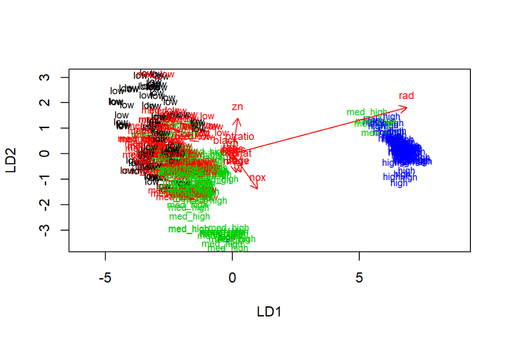

```r
# the function for lda biplot arrows
lda.arrows <- function(x, myscale = 1, arrow_heads = 0.1, color = "red", tex = 0.75, choices = c(1,2)){
  heads <- coef(x)
  arrows(x0 = 0, y0 = 0,
         x1 = myscale * heads[,choices[1]],
         y1 = myscale * heads[,choices[2]], col=color, length = arrow_heads)
  text(myscale * heads[,choices], labels = row.names(heads),
       cex = tex, col=color, pos=3)
}

# target classes as numeric
classes <- as.numeric(train$crime)

# plot the lda results
plot(lda.fit, dimen = 2, col=classes, pch=classes)
lda.arrows(lda.fit, myscale = 2)
```

The most influential variables are those with longer arrows in the plot, so rad, nox (nitrogen oxides concentration) and zn (proportion of residential land zoned for lots over 25,000 sq.ft). We now predict the classes with the LDA model on the test data and cross tabulate the results with the crime categories from the test set.

```r
# predict classes with test data
lda.pred <- predict(lda.fit, newdata = test)

# cross tabulate the results
table(correct = correct_classes, predicted = lda.pred$class)
```

```
##           predicted
## correct    low med_low med_high high
##   low       19      11        0    0
##   med_low    8      13        4    0
##   med_high   0      10       12    2
##   high       0       0        0   23
```